# Project Introduction

Cancer has affected many people around the world. Unfortunately, we have not found a consistent, preventative cure to stop the deadly disease. In this project, we will use convolutional neural networks to classify images that will identify metastatic cancer from digital pathology scans.

Our data comes from the [Kaggle Hispatholofic Cancer Detection](https://www.kaggle.com/c/histopathologic-cancer-detection) competition. Overall, the data is split into two different sets: a training set consisting of 220,025 images and a test set consisting of 57,458. Each image has a dimension of 96 x 96 x 3. The 96 x 96 corresponds to the pixel width and height. The 3 consists of the "depth" or the color dimension of the image. In our case, we have a dimension of 3 which means our images are on the RGB color scale.

**Note: Due to the large file size, the data was not uploaded to the github repository** First, we load in the necessary packages needed to build our neural network

```python
import pandas as pd
import numpy as np
import matplotlib.pyplot as plt
import plotly.express as px
import seaborn as sns
from sklearn.model_selection import train_test_split
from mpl_toolkits.mplot3d import Axes3D


import os
import cv2
import pickle

import tensorflow as tf
from tensorflow.keras.models import Sequential, load_model
from tensorflow.keras.layers import Dense, Dropout, Activation, Flatten, Conv2D, MaxPooling2D
from tensorflow.keras.optimizers import Adam, RMSprop
from tensorflow.keras.callbacks import EarlyStopping

from IPython.display import Image


TRAIN_PATH = "../data_cancer/train"
TEST_PATH = "../data_cancer/test"
PICKLE_PATH = "../data_cancer/pickled/"
```

```python
!pip install plotly
```

# Dataset Creation and Cleaning

Originally, the images of our dataset were shaped in 4 dimension (1, 96, 96, 3). To properly process as images, each file was reshaped to (96,96,3) and loaded into an array. This was appplied to both the training and test datasets.

The filename of the images also consists of that images Id with a *tif* extension. Thus, we also create lists of each image's file name. This is important as we train our data as we want the correct label matched with the correct image dimensions.

**Note: Because this takes a while to process, the original code is commented out. However, the original data is saved as pickeled file. This allows the state of the objects to be loaded in the state they were saved**

```python
#Still need to order the train labels with the X_train images and labels
#Can use the labels from X test to
file_train = "file_id_train"
file_test = "file_id_test"

## Create arrays for with dimensions consistent with images
# X_train = np.zeros([len(os.listdir(TRAIN_PATH)),96,96,3], dtype = np.uint8)
# X_test = np.zeros([len(os.listdir(TEST_PATH)),96,96,3], dtype = np.uint8)

## List for the filenames (also IDs) in the order the images are loaded in
# file_id_train = []
# file_id_test = []

## Get ID and images in training dataset
# for i, img in enumerate(os.listdir(TRAIN_PATH)):
#     file_id_train.append(img)
#     pic = cv2.imread(os.path.join(TRAIN_PATH,img))
#     X_train[i] = pic

## Get ID and images in test set
# for i, img in enumerate(os.listdir(TEST_PATH)):
#     file_id_test.append(img)
#     pic = cv2.imread(os.path.join(TEST_PATH,img))
#     X_test[i] = pic
```

```python
## Create directory and save both datasets and labels as binary file
# if not os.path.exists(PICKLE_PATH):
#     os.makedirs(PICKLE_PATH)

# np.save("../data_cancer/pickled/X_train.npy", X_train)
# np.save("../data_cancer/pickled/X_test.npy", X_test)

# with open(os.path.join(PICKLE_PATH, file_train), "wb") as list_dump:
#     pickle.dump(file_id_train, list_dump)

# with open(os.path.join(PICKLE_PATH, file_test), "wb") as list_dump:
#     pickle.dump(file_id_test, list_dump)
```

Here we load the our datasets that we created. As stated in the note beforehand, the state of the objects are loaded in as they were saved.

```python
#Load features of images
X_train = np.load(PICKLE_PATH + "X_train.npy")
X_test = np.load(PICKLE_PATH + "X_test.npy")

#Load IDs for dataset
with open(os.path.join(PICKLE_PATH, file_train), "rb") as train_id_file:
         train_ids = pickle.load(train_id_file)

with open(os.path.join(PICKLE_PATH, file_test), "rb") as test_id_file:
         test_ids = pickle.load(test_id_file)

#load labels for training set
labels = pd.read_csv("../data_cancer/train_labels.csv")
```

Here we can tell the images were loaded in properly.

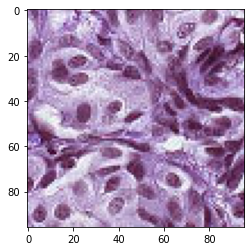

```python
plt.imshow(X_train[1])
```

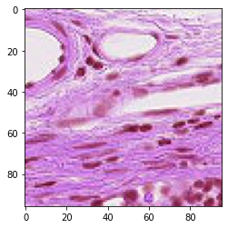

```python
plt.imshow(X_test[1])
```

### Mapping Training Image to Correct Label

As stated before, the file names consist of the id of the image. As we can see, the given classification labels for our dataset are not in the order of our feature dataset (the images themselves). Thefore, we need to correctly map the labels of the images to the image features. By creating a dataframe from the `train_ids` list and removing teh *tif* extension, we can create a dataframe in which we can map the correct labels use a left merge with the `labels` dataframe

```python
labels.head(5)
```

|  | id | label |
| --- | --- | --- |
| 0 | f38a6374c348f90b587e046aac6079959adf3835 | 0 |
| 1 | c18f2d887b7ae4f6742ee445113fa1aef383ed77 | 1 |
| 2 | 755db6279dae599ebb4d39a9123cce439965282d | 0 |
| 3 | bc3f0c64fb968ff4a8bd33af6971ecae77c75e08 | 0 |
| 4 | 068aba587a4950175d04c680d38943fd488d6a9d | 0 |

```python
train_ids[:5]
```

```
['f0c2a0b8ef3024f407fa97d852d49be0215cafe0.tif',
 '99ef485f205645918613cd04281098daa7c17819.tif',
 'e2612e173abd0e8bb54a3c3db3f264b63d80bffb.tif',
 '6d1bb57c0606f05dbd75f90a8d9e21a57e1267e0.tif',
 '9c043ab2adadfeb758c71d21432fccd3e43565c0.tif']
```

```python
#remove ".tif" from each image IF
train_ids = pd.DataFrame(train_ids, columns=["id"])
train_ids["id"] = train_ids["id"].str[:-4]

test_ids = pd.DataFrame(test_ids, columns=["id"])
test_ids["id"] = test_ids["id"].str[:-4]

#Create dataframe of labels in order of the images of the feature set
train_labels = train_ids.merge(labels, how="left")
```

```python
train_labels.info()
```

```
<class 'pandas.core.frame.DataFrame'>
Int64Index: 220025 entries, 0 to 220024
Data columns (total 2 columns):
 #   Column  Non-Null Count   Dtype
---  ------  --------------   -----
 0   id      220025 non-null  object
 1   label   220025 non-null  int64
dtypes: int64(1), object(1)
memory usage: 5.0+ MB
```

```python
test_ids.info()
```

```
<class 'pandas.core.frame.DataFrame'>
RangeIndex: 57458 entries, 0 to 57457
Data columns (total 1 columns):
 #   Column  Non-Null Count  Dtype
---  ------  --------------  -----
 0   id      57458 non-null  object
dtypes: object(1)
memory usage: 449.0+ KB
```

```python
train_labels.head(5)
```

|  | id | label |
| --- | --- | --- |
| 0 | f0c2a0b8ef3024f407fa97d852d49be0215cafe0 | 0 |
| 1 | 99ef485f205645918613cd04281098daa7c17819 | 1 |
| 2 | e2612e173abd0e8bb54a3c3db3f264b63d80bffb | 1 |
| 3 | 6d1bb57c0606f05dbd75f90a8d9e21a57e1267e0 | 0 |
| 4 | 9c043ab2adadfeb758c71d21432fccd3e43565c0 | 1 |

```python
test_ids.head(5)
```

|  | id |
| --- | --- |
| 0 | fd0a060ef9c30c9a83f6b4bfb568db74b099154d |
| 1 | 1f9ee06f06d329eb7902a2e03ab3835dd0484581 |
| 2 | 19709bec800f372d0b1d085da6933dd3ef108846 |
| 3 | 7a34fc34523063f13f0617f7518a0330f6187bd3 |
| 4 | 93be720ca2b95fe2126cf2e1ed752bd759e9b0ed |

# Visualization

Visualization teechniques for images are limited due to the structure of the data. However, we can visualize different things such as the distribution of our labels and the difference between photos of images that have cancer and ones that do not.

### Validation Set

Last lets create a validation set to evaluate our training models.

We can see our training set will consist of 176020 images and the validation set will have 44005. Each image has a shape of 96x96x3.

```python
X_train, X_valid, train_labels, valid_labels = train_test_split(X_train, train_labels,
                                                                test_size=0.2, random_state=726427)
```

```python
print("X_train shape: ", X_train.shape)
print("X_valid shape: ", X_valid.shape)
print("train_labels shape: ", train_labels.shape)
print("valid_labels shape: ", valid_labels.shape)
```

```
X_train shape:  (176020, 96, 96, 3)
X_valid shape:  (44005, 96, 96, 3)
train_labels shape:  (176020, 2)
valid_labels shape:  (44005, 2)
```

```python
train_labels.head()
```

|  | id | label |
| --- | --- | --- |
| 205526 | 3e8d2a5d3f9c52fa1f53bd0bbff4f0bf3eb754b4 | 1 |
| 121494 | f0979635c1ee6aa55b3203d9941da28103423fbf | 1 |
| 108530 | a979b5fe5ef5ca5b89a9ffbcb151aadf0bf563f6 | 1 |
| 10449 | 835c65cc16d2277c62fe3c689a72dadd48258f98 | 1 |
| 99844 | 37bac34613b50764e9d5ffad8db1ef504ff8de93 | 0 |

### Distribution of Labels

As we can see from the plot below, there seems to be more photos negative of metastatic Cancer compared to positive. This imbalance could cause issues with accuracy. However, for our problem we are more concerned with the recall of the model. In other words, we want to make sure we catch the cancer; we will do this even if it is at the cost of classifying more negative results as positive. Thus, keeping this imbalance could help us accurately find that relationship.

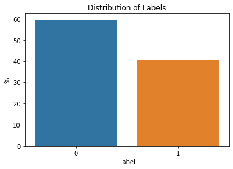

```python
norm_df = train_labels["label"].value_counts(normalize=True).mul(100).reset_index().rename(
        columns={'index': "Label", "label": "%"})

sns.barplot(x="Label",y='%', data=norm_df)
plt.title("Distribution of Labels")
```

```python
#Get separate dataframes for images positive for metastatic cancer and images that are negative

train_labels.reset_index(drop=True, inplace=True)
pos_labels = np.array(train_labels[train_labels["label"] == 1].index)
neg_labels = np.array(train_labels[train_labels["label"] == 0].index)

pos_ftr_mtrx = X_train[pos_labels]
neg_ftr_mtrx = X_train[neg_labels]

y_train = np.array(train_labels["label"])
```

```python
y_valid = np.array(valid_labels["label"])
```

### Looking at Images

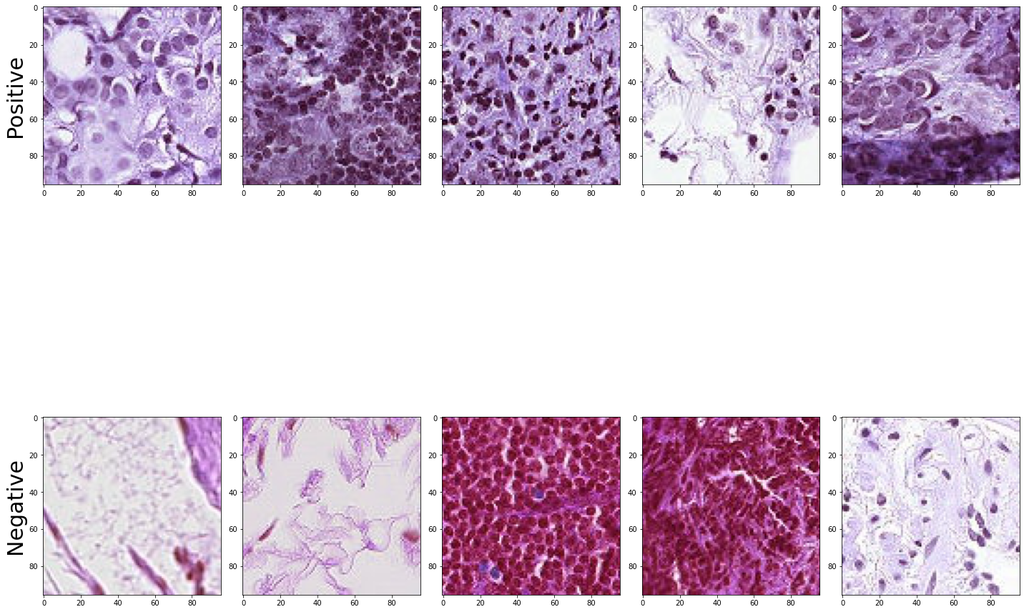

```python
fig, ax = plt.subplots(2,5, figsize=(20,20))

ax[0,0].imshow(pos_ftr_mtrx[0])
ax[0,1].imshow(pos_ftr_mtrx[1])
ax[0,2].imshow(pos_ftr_mtrx[2])
ax[0,3].imshow(pos_ftr_mtrx[3])
ax[0,4].imshow(pos_ftr_mtrx[4])
ax[0,0].set_ylabel("Positive", fontsize=30)

ax[1,0].imshow(neg_ftr_mtrx[0])
ax[1,1].imshow(neg_ftr_mtrx[1])
ax[1,2].imshow(neg_ftr_mtrx[2])
ax[1,3].imshow(neg_ftr_mtrx[3])
ax[1,4].imshow(neg_ftr_mtrx[4])
ax[1,0].set_ylabel("Negative", fontsize=30)

fig.tight_layout()
```

# Model Creation

We will compare three models and choose the one with the best accuracy. Note, if this wasn't a kaggle submission, we would most likely be concerned with the recall and not the accuracy. By focusing on improving recall, we can be sure we identify someone with the cancer.

- I will use a 3x3 **filter size** for each model. I want to use a smaller filter to capture the local differences in each picture. As we saw by our picture visualizations, we cannot see the differences by the naked eye. Therefore, using a smaller filter size will allow use to capture those local smaller differences. However, a 1x1 filter will create feature maps that are the same size as our input. Also, this will have a high chance of overfitting the model
- The architecture will differ in points of how many **convolutional layers** I will use. The three models will consist of 2, 4 and 5 convolutional layers. I believe, 2 layers will underfit the data. It will perform with the lowest accuracy on both the test set and dataset. However, the model with 4 convolutional layers will perform well while 5 layers will slightly overfit.
- Next, I will use **Max pooling** for the pooling layer for all models. The size of this will be 2x2. First, max pooling is used instead of average pooling becauase it is better at recognizing distringuishable features due to identifying extreme values in specific areas. Average pooling would create feature maps that don't idenify the important features, instead it would make different areas seem more similar or "smoother". Max pooling will help use identify an object no matter where it is at.
  - A **2x2** pooling is used on all models because if I use anymore there will be too much data lost since our pooling layers are essentially a generalization layer.
- **Binary Crossentropy** will be used as a loss function. Our model has a binary output. Thus using a loss function that idenitfies with a binary output is important. More specifically, we want to heavily penalize the models that have a lower probability for the correct class. Thus, Binary Crossentropy is the perfect metric for our model.
- Again, we have a binary output classification problem. Thus, the best activation function for our output layer is the **sigmoid** function
- **We will hypertune our** optimizer **and** learning rate **once we choose our model**

```python
#Create directories to store metrics and models
MODEL_PATH = "Models/"
if not os.path.exists(MODEL_PATH):
    os.makedirs(MODEL_PATH)

if not os.path.exists(MODEL_PATH + "Metrics"):
    os.makedirs(MODEL_PATH + "Metrics")
```

```python
#Model with 2 hidden layers
model1 = Sequential()
model1.add(Conv2D(64, (3,3), input_shape=(96,96,3)))
model1.add(Activation("relu"))
model1.add(MaxPooling2D(pool_size=(2,2)))

model1.add(Conv2D(64, (3,3)))
model1.add(Activation("relu"))
model1.add(MaxPooling2D(pool_size=(2,2)))

model1.add(Flatten())
model1.add(Dense(64))

model1.add(Dense(1))
model1.add(Activation('sigmoid'))

model1.compile(loss="binary_crossentropy",
              optimizer="adam",
              metrics=["accuracy"]
             )
model1.fit(X_train, y_train, batch_size=128, epochs=5, validation_split=0.1)
```

```
<keras.callbacks.History at 0x7fec4264b8e0>
```

```python
#Save model with 2 layers and its history
if not os.path.exists(MODEL_PATH):
    os.makedirs(MODEL_PATH)

model1.save(MODEL_PATH + "two_lyr_model")

with open(MODEL_PATH + "Metrics/two_lyr_hist", 'wb') as file_hist:
    pickle.dump(model1.history, file_hist)
```

```
INFO:tensorflow:Assets written to: Models/two_lyr_model/assets
INFO:tensorflow:Assets written to: ram://79b7a471-39eb-48d7-a434-c036fd083ad9/assets
```

```python
#Createmodel with 4 layers and its history
model2 = Sequential()
model2.add(Conv2D(64, (3,3), input_shape=(96,96,3)))
model2.add(Activation("relu"))
model2.add(MaxPooling2D(pool_size=(2,2)))

model2.add(Conv2D(64, (3,3)))
model2.add(Activation("relu"))
model2.add(MaxPooling2D(pool_size=(2,2)))

model2.add(Conv2D(64, (3,3)))
model2.add(Activation("relu"))
model2.add(MaxPooling2D(pool_size=(2,2)))

model2.add(Conv2D(64, (3,3)))
model2.add(Activation("relu"))
model2.add(MaxPooling2D(pool_size=(2,2)))

model2.add(Flatten())
model2.add(Dense(64))

model2.add(Dense(1))
model2.add(Activation('sigmoid'))

model2.compile(loss="binary_crossentropy",
              optimizer="adam",
              metrics=["accuracy"]
             )
model2.fit(X_train, y_train, batch_size=128, epochs=5, validation_split=0.1)
```

```
<keras.callbacks.History at 0x7fec3f629cd0>
```

```python
if not os.path.exists(MODEL_PATH):
    os.makedirs(MODEL_PATH)

model.save(MODEL_PATH + "four_lyr_model")
with open(MODEL_PATH + "Metrics/four_lyr_hist", 'wb') as file_hist:
    pickle.dump(model.history, file_hist)
```

```
INFO:tensorflow:Assets written to: ram://b5524cf1-b685-4221-b606-4e8d1ee23752/assets
```

```python
#Create Model with 5 hidden layers
model3 = Sequential()
model3.add(Conv2D(64, (3,3), input_shape=(96,96,3)))
model3.add(Activation("relu"))
model3.add(MaxPooling2D(pool_size=(2,2)))

model3.add(Conv2D(64, (3,3)))
model3.add(Activation("relu"))
model3.add(MaxPooling2D(pool_size=(2,2)))

model3.add(Conv2D(64, (3,3)))
model3.add(Activation("relu"))
model3.add(MaxPooling2D(pool_size=(2,2)))

model3.add(Conv2D(64, (3,3)))
model3.add(Activation("relu"))
model3.add(MaxPooling2D(pool_size=(2,2)))

model3.add(Conv2D(64, (3,3)))
model3.add(Activation("relu"))
model3.add(MaxPooling2D(pool_size=(2,2)))

model3.add(Flatten())
model3.add(Dense(64))

model3.add(Dense(1))
model3.add(Activation('sigmoid'))

model3.compile(loss="binary_crossentropy",
              optimizer="adam",
              metrics=["accuracy"]
             )
model3.fit(X_train, y_train, batch_size=128, epochs=5, validation_split=0.1)
```

```
<keras.callbacks.History at 0x7fec40d5d7f0>
```

```python
if not os.path.exists(MODEL_PATH):
    os.makedirs(MODEL_PATH)

model3.save(MODEL_PATH + "5_layer_model")

with open(MODEL_PATH + "Metrics/5_lyr_hist", 'wb') as file_hist:
    pickle.dump(model3.history, file_hist)
```

```
INFO:tensorflow:Assets written to: Models/5_layer_model/assets
INFO:tensorflow:Assets written to: ram://3bf9eeb2-2045-456f-89b4-9a12cbdb109e/assets
```

# Model Selection

```python
#Load the Saved models

model1 = load_model(MODEL_PATH + "two_lyr_model")
model2 = load_model(MODEL_PATH + "four_lyr_model")
model3 = load_model(MODEL_PATH + "5_layer_model")
```

```python
#Load the model history
hist1 = pickle.load(open(MODEL_PATH + "two_lyr_hist", 'rb'))
hist2 = pickle.load(open(MODEL_PATH + "four_lyr_hist", 'rb'))
hist3 = pickle.load(open(MODEL_PATH + "5_lyr_hist", 'rb'))
```

### Validation vs Test Accuracy

Also, testing on our own separate validate set, we can see model three is still the best performer.

```python
def plot_acc(history, axis = None, model=None, ylim=None):
    """ Plots a models validation and training accuracy"""
    axis.plot(history.history['accuracy'], label='accuracy')
    axis.plot(history.history['val_accuracy'], label='val_accuracy')
    axis.set_xlabel('Epoch')
    axis.set_ylabel('accuracy')
    axis.set_title(model)
    axis.set_ylim(ylim)
    axis.legend(loc='lower right')

def plot_val(history, axis=None, model=None):
    "Plot's a models lossat each epoch"
    axis.plot(history.history['loss'], label='loss')
    axis.plot(history.history['val_loss'], label='val_loss')
    axis.set_xlabel('Epoch')
    axis.set_ylabel('Loss')
    axis.set_title(model)
    axis.legend(loc='upper right')
```

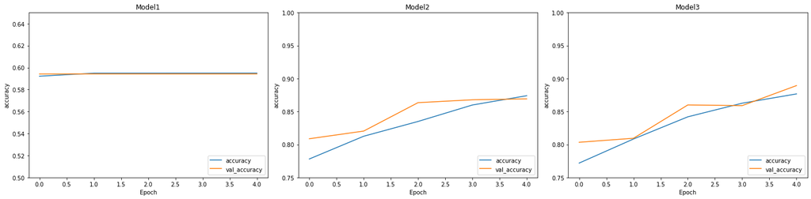

```python
fig, ax = plt.subplots(1,3, figsize=(20,5))
plot_acc(hist1, axis=ax[0], model="Model1", ylim=[0.5, 0.65])
plot_acc(hist2, axis=ax[1], model="Model2", ylim = [0.75, 1])
plot_acc(hist3, axis=ax[2], model="Model3", ylim= [0.75, 1])
fig.tight_layout()
```

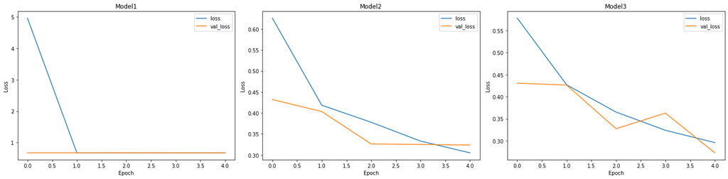

```python
fig, ax = plt.subplots(1,3, figsize=(20,5))
plot_val(hist1, axis=ax[0], model="Model1")
plot_val(hist2, axis=ax[1], model="Model2")
plot_val(hist3, axis=ax[2], model="Model3")
fig.tight_layout()
```

```python
#Create table of metrics
model_list = [model1, model2, model3]
model_name = ["model1", "model2", "model3"]
loss_list = []
acc_list = []
for mod in model_list:
    val_loss, val_acc = mod.evaluate(X_valid, y_valid)
    loss_list.append(val_loss)
    acc_list.append(val_acc)
```

```python
stat_df = pd.DataFrame({"Model": model_name, "Loss" : loss_list, "Accuracy": acc_list})
stat_df.sort_values(by="Accuracy", ascending=False)
```

|  | Model | Loss | Accuracy |
| --- | --- | --- | --- |
| 2 | model3 | 0.274853 | 0.887763 |
| 1 | model2 | 0.330292 | 0.864061 |
| 0 | model1 | 0.674826 | 0.595364 |

# Hyperparameter Tuning

Our best **learning rate** is 0.001 and our best **optimizer** is Adam.

```python
lr_list = [0.001, 0.01, 0.1]
optimizer_list = [Adam, RMSprop]
optimizer = ""

#lists for metrics
lr_used_list = []
opt_name_list = []
val_list = []
acc_list = []

for lr in lr_list:
    for opt in optimizer_list:
        #Get name of optimizer used
        if opt == Adam:
            optimizer = "Adam"
        else:
            optimizer = "RMSprop"
        model3.compile(
            loss="binary_crossentropy",
            optimizer=opt(learning_rate =lr),
            metrics=["accuracy"]
        )

        #Fit the model
        model3.fit(X_train, y_train, batch_size=128, epochs=1, validation_split=0.1)

        #Get metrics and store for analysis
        val_loss, val_acc = model3.evaluate(X_valid, y_valid)
        lr_used_list.append(lr)
        opt_name_list.append(optimizer)
        val_list.append(val_loss)
        acc_list.append(val_acc)
```

```python
tuning_df = pd.DataFrame({"Learning Rate": lr_used_list, "Optimizer": opt_name_list, "Loss": val_list,
                          "Accuracy": acc_list})
tuning_df.sort_values(by="Accuracy", ascending=False)
tuning_df.to_csv(MODEL_PATH + "Metrics/hyperparams")
```

[output not shown]

# Final Model

Here, we will build our final model using the architecture from model 3 and the hyperparameters from our hypertuning

```python
from sklearn.metrics import roc_auc_score, classification_report, confusion_matrix
```

```python
#Build the final model
model3 = load_model(MODEL_PATH + "5_layer_model")
model3.compile(
    loss="binary_crossentropy",
    optimizer=Adam(learning_rate =0.001),
    metrics=["accuracy"])

model3.fit(X_train, y_train, batch_size=128, epochs=4, validation_split=0.1)
model3.save(MODEL_PATH + "final_model")
```

```
<keras.callbacks.History at 0x7fec4d52c1c0>
```

```python
val_predictions = final_model.predict(X_valid)
val_predictions = np.array(tf.greater(val_predictions, 0.5)).astype(int)
val_predictions = val_predictions.ravel()
val_predictions
```

```
array([0, 0, 1, ..., 1, 0, 1])
```

# Evaluation

```
              precision    recall  f1-score   support

           0       0.93      0.89      0.91     26199
           1       0.85      0.90      0.87     17806

    accuracy                           0.89     44005
   macro avg       0.89      0.89      0.89     44005
weighted avg       0.89      0.89      0.89     44005

The Area Under the Curve Score is:  0.8937445704377485
```

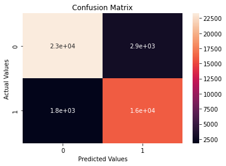

```python
print(classification_report(y_valid, val_predictions))
print("The Area Under the Curve Score is: ", roc_auc_score(y_valid, val_predictions))

sns.heatmap(confusion_matrix(y_valid, val_predictions), annot=True)
plt.title("Confusion Matrix")
plt.xlabel("Predicted Values")
plt.ylabel("Actual Values")
```

# Conclusion and Kaggle Results

```python
#Get final model predictions
final_model =load_model(MODEL_PATH + "final_model")
predictions = final_model.predict(X_test)
predictions = np.array(tf.greater(predictions, 0.5)).astype(int)
predictions = predictions.ravel()
predictions

#Save predictions
with open(MODEL_PATH + "Metrics/predictions", 'wb') as preds:
    pickle.dump(predictions, preds)
```

```python
predictions = pickle.load(open(MODEL_PATH + "Metrics/predictions", "rb"))
test_ids["label"] = list(predictions)
```

```python
test_ids
```

|  | id | label |
| --- | --- | --- |
| 0 | fd0a060ef9c30c9a83f6b4bfb568db74b099154d | 0 |
| 1 | 1f9ee06f06d329eb7902a2e03ab3835dd0484581 | 0 |
| 2 | 19709bec800f372d0b1d085da6933dd3ef108846 | 0 |
| 3 | 7a34fc34523063f13f0617f7518a0330f6187bd3 | 0 |
| 4 | 93be720ca2b95fe2126cf2e1ed752bd759e9b0ed | 0 |
| ... | ... | ... |
| 57453 | 2581931c6ef068f105a872f2c5500275fc678242 | 0 |
| 57454 | 11b250a664d09ab59fd2afbdb2f8d786763b185d | 1 |
| 57455 | 18a6030935ec1ef1ce486ec51bc95abb4008fbf1 | 0 |
| 57456 | f541404e501e23a0188c852eb37eac94053cfdc0 | 0 |
| 57457 | 3cb6f5e2db8ad046c946b581fa12d20df5ce2927 | 1 |

57458 rows × 2 columns

```python
# test_ids.to_csv('test_ids.csv', index = False)
```

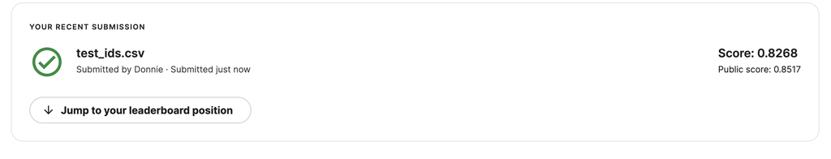

```python
Image('submission.png')
```